# R Notebook

```r
library(ggplot2)
library(readr)
library(dplyr)
library(tidyr)
library(Hmisc)
library(ggplot2)
library(ggpubr)
library(cowplot)
library(corrr)
library(leaflet)
library(leaflet.extras)
library(wesanderson)
library(tidyverse)
library(ggcorrplot)
```

```r
spot_data <- read.csv("spotify.csv")
head(spot_data)
str(spot_data)
```

```r
popularityYearPlot<-spot_data%>%group_by(year)%>%
  summarise(averagePopularity=mean(popularity))%>%
  ggplot(aes(year,averagePopularity))+geom_line()+labs(y="Average Popularity",x="Year")
popularityYearPlot
```

Filter data for 2019:

```r
data_2019 <- spot_data %>% filter(year == 2019)
head(data_2019)
str(data_2019)
```

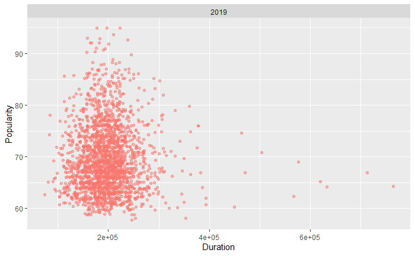

```r
plot<-ggplot(data_2019)
plot1<-plot+geom_point(aes(x=duration_ms,y=popularity, color=as.factor(year)), alpha=0.5, position = position_jitter())+
  labs(color="Year", x='Duration', y="Popularity")+facet_wrap(~year)+theme(legend.position = "none")
plot1
```

Pre-analysis by plotting duration and popularity for data in 2019:

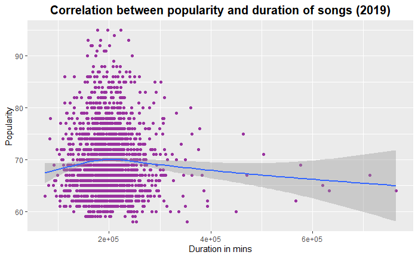

```r
plot2019<-data_2019%>%ggplot(aes(duration_ms,popularity))+
  geom_point(color="#99329F")+geom_smooth(aes(duration_ms,popularity))+
  labs(x='Duration in mins',y='Popularity')+ggtitle("Correlation between popularity and duration of songs (2019)")+
  theme(plot.title = element_text(size = 15,face = "bold",hjust = 0.5))
plot2019
```

```r
ggplot(data_2019, aes(x = duration_ms , y = popularity)) +
  geom_point()
```

Checking for correlations:

```r
cor(data_2019$duration, data_2019$popularity)
cor(data_2019$speechines, data_2019$popularity)
```

Reading file data_w_genres since we believe this will reproduce better information about correlations between variables and popularity. Moreover, we expect different variables to have different weights when in comes to popularity:

```r
data_w_genres <- read.csv("data_w_genres.csv")
data_w_genres[10000:10010 , ]
```

|  | artists | acousticness | danceability | duration_ms | energy | instrumentalness | liveness | loudness | speechiness | tempo | valence | popularity | key | mode | count | genres |
| --- | --- | --- | --- | --- | --- | --- | --- | --- | --- | --- | --- | --- | --- | --- | --- | --- |
| 10000 | Hiroaki Tommy Tominaga | 0.09860000 | 0.4290000 | 262567.0 | 0.9790000 | 0.00000232 | 0.3020000 | -2.204000 | 0.11900000 | 146.1450 | 0.4340000 | 65.00000 | 7 | 0 | 2 | ['otacore'] |
| 10001 | Hiroshi Kitadani | 0.20600000 | 0.3320000 | 262013.0 | 0.9750000 | 0.00000000 | 0.9810000 | -6.182000 | 0.10600000 | 167.8740 | 0.2680000 | 48.00000 | 8 | 1 | 2 | [] |
| 10002 | Hiroshi Sato | 0.48400000 | 0.7720000 | 206320.0 | 0.6700000 | 0.00024900 | 0.0545000 | -8.514000 | 0.05630000 | 111.0190 | 0.8820000 | 39.00000 | 5 | 1 | 2 | ['japanese city pop'] |
| 10003 | Hiroshima | 0.33815714 | 0.7000000 | 299826.7 | 0.4847143 | 0.39034856 | 0.1192429 | -14.624857 | 0.03671429 | 119.5383 | 0.6888571 | 29.71429 | 0 | 1 | 14 | ['jazz funk', 'smooth jazz'] |
| 10004 | Hiroyuki Sawano | 0.13089333 | 0.4003333 | 301364.3 | 0.5823333 | 0.55667583 | 0.2064000 | -9.493333 | 0.06096667 | 109.1747 | 0.2072000 | 57.66667 | 11 | 0 | 6 | ['anime score', 'japanese soundtrack', 'otacore'] |
| 10005 | Hirth Martinez | 0.51100000 | 0.6730000 | 236844.0 | 0.4810000 | 0.05630000 | 0.0837000 | -15.616000 | 0.07020000 | 78.6860 | 0.8740000 | 35.00000 | 4 | 0 | 2 | [] |
| 10006 | His BBC Dance Orchestra | 0.95612000 | 0.6091600 | 179020.2 | 0.2090200 | 0.09610807 | 0.1584360 | -18.959000 | 0.07843200 | 126.5800 | 0.6400000 | 1.68000 | 0 | 1 | 50 | [] |
| 10007 | His Orchestra | 0.97600000 | 0.4790000 | 185133.0 | 0.1850000 | 0.00122000 | 0.3040000 | -14.009000 | 0.05220000 | 122.1040 | 0.3310000 | 5.00000 | 9 | 1 | 2 | [] |
| 10008 | Hiss Golden Messenger | 0.64900000 | 0.6810000 | 358440.0 | 0.3190000 | 0.00005700 | 0.1130000 | -9.927000 | 0.03950000 | 121.7830 | 0.2100000 | 57.00000 | 3 | 1 | 2 | ['alternative country', 'deep new americana', 'indie folk', 'indie pop', 'indie rock', 'modern folk rock', 'new americana', 'north carolina indie', 'roots rock', 'stomp and holler'] |
| 10009 | Hit The Lights | 0.03120000 | 0.5670000 | 189253.0 | 0.9400000 | 0.00000000 | 0.4110000 | -3.155000 | 0.09400000 | 116.5230 | 0.5590000 | 49.00000 | 9 | 1 | 2 | ['anthem emo', 'easycore', 'neon pop punk', 'pixie', 'pop emo', 'pop punk'] |

[output cut: 1 more lines]

```r
#checking for unique genres... list is long, but we will be dividing it into 4 main groups:
#all_genres <- unique(data_w_genres$genres)
#all_genres
```

In the following lines, we will be separing data into rock, rap, jazz, and pop - the four broad categories we have found in the data. We are also filtering for some songs that might have mixed genres, i.e.: pop rock, rap rock, jazz rock, etc…

```r
##This makes rock songs their own table and assigns the general genre "genGenre" to Rock

rock_songs <- data_w_genres[grep("rock" , data_w_genres$genres, value = FALSE), ]
rock_songs$genGenre = "rock"
head(rock_songs)
```

|  | artists | acousticness | danceability | duration_ms | energy | instrumentalness | liveness | loudness | speechiness | tempo | valence | popularity | key | mode | count | genres | genGenre |
| --- | --- | --- | --- | --- | --- | --- | --- | --- | --- | --- | --- | --- | --- | --- | --- | --- | --- |
| 10 | "Weird Al" Yankovic | 0.1769341 | 0.6647879 | 218165.3 | 0.6851364 | 4.631758e-05 | 0.1621394 | -9.877909 | 0.08239242 | 132.4951 | 0.7544091 | 33.68182 | 9 | 1 | 132 | ['antiviral pop', 'comedy rock', 'comic', 'parody'] | rock |
| 20 | 'Til Tuesday | 0.1055563 | 0.5571250 | 255213.5 | 0.6122500 | 2.330025e-02 | 0.1275875 | -9.638125 | 0.03215000 | 103.0803 | 0.5326250 | 35.12500 | 0 | 1 | 16 | ['boston rock', 'dance rock', 'new romantic', 'new wave', 'new wave pop'] | rock |
| 25 | (Hed) P.E. | 0.0116314 | 0.5892000 | 253677.4 | 0.8792000 | 2.026000e-06 | 0.1711200 | -5.259800 | 0.17214000 | 134.9694 | 0.4270000 | 45.80000 | 2 | 1 | 10 | ['alternative metal', 'industrial metal', 'nu metal', 'post-grunge', 'rap metal', 'rap rock'] | rock |
| 28 | - | 0.4660000 | 0.4460000 | 316307.0 | 0.5460000 | 1.540000e-05 | 0.1930000 | -7.022000 | 0.04500000 | 125.9610 | 0.3760000 | 55.00000 | 10 | 0 | 2 | ['alternative pop rock', 'neon pop punk', 'pop emo', 'pop punk', 'texas pop punk'] | rock |
| 29 | ...And You Will Know Us by the Trail of Dead | 0.0084100 | 0.2550000 | 273624.0 | 0.8580000 | 3.550000e-04 | 0.5130000 | -5.085000 | 0.06940000 | 144.6530 | 0.2370000 | 35.00000 | 7 | 1 | 2 | ['alternative rock', 'dance-punk', 'indie rock', 'lo-fi', 'modern rock', 'post-hardcore'] | rock |
| 33 | 10 Ft. Ganja Plant | 0.1083500 | 0.7875000 | 256780.0 | 0.7725000 | 8.465000e-01 | 0.0773500 | -4.744000 | 0.07285000 | 142.9730 | 0.8340000 | 48.50000 | 2 | 0 | 4 | ['dub', 'east coast reggae', 'reggae', 'reggae rock', 'roots reggae'] | rock |

```r
#This does the same thing for Rap:

rap_songs <- data_w_genres[grep("rap", data_w_genres$genres, value = FALSE) , ]

#Then we eliminate genres that also have rock in them to maintain mainly rap:
only_rap_songs <- rap_songs %>% filter(str_detect(rap_songs$genres, "rock") == FALSE)
only_rap_songs$genGenre = "rap"
```

```r
head(only_rap_songs)
```

|  | artists | acousticness | danceability | duration_ms | energy | instrumentalness | liveness | loudness | speechiness | tempo | valence | popularity | key | mode | count | genres | genGenre |
| --- | --- | --- | --- | --- | --- | --- | --- | --- | --- | --- | --- | --- | --- | --- | --- | --- | --- |
| 1 | $NOT | 0.5470000 | 0.7501250 | 152929.5 | 0.5197500 | 0.04313714 | 0.2139750 | -8.878500 | 0.2767250 | 114.2291 | 0.3195000 | 64.62500 | 6 | 1 | 8 | ['east coast hip hop', 'gangster rap', 'hardcore hip hop', 'hip hop', 'rap'] | rap |
| 2 | $uicideBoy$ | 0.1281226 | 0.7652459 | 147549.4 | 0.6417049 | 0.03845447 | 0.2011951 | -6.626918 | 0.1559172 | 119.8044 | 0.2960959 | 61.64754 | 1 | 1 | 122 | ['dark trap', 'new orleans rap', 'underground hip hop'] | rap |
| 3 | ((( O ))) | 0.8470000 | 0.4100000 | 311837.0 | 0.1690000 | 0.00327000 | 0.1170000 | -11.422000 | 0.0485000 | 89.4940 | 0.2080000 | 66.00000 | 3 | 1 | 2 | ['latin', 'puerto rican pop', 'reggaeton', 'trap latino'] | rap |
| 4 | 03 Greedo | 0.0693200 | 0.7246000 | 220595.2 | 0.6938000 | 0.00000080 | 0.1650600 | -5.021000 | 0.0507400 | 93.9078 | 0.4434000 | 59.20000 | 1 | 0 | 5 | ['cali rap', 'melodic rap', 'trap', 'underground hip hop', 'vapor trap'] | rap |
| 5 | 070 Shake | 0.3751333 | 0.6800000 | 303688.7 | 0.6370000 | 0.00000232 | 0.1242667 | -9.293667 | 0.1089000 | 112.6787 | 0.3456667 | 63.00000 | 4 | 0 | 3 | ['alternative r&b', 'indie r&b', 'new jersey rap'] | rap |
| 6 | 11/5 | 0.2700000 | 0.9290000 | 182373.0 | 0.6610000 | 0.00000152 | 0.0879000 | -6.794000 | 0.1710000 | 114.9730 | 0.7080000 | 37.00000 | 1 | 0 | 2 | ['dirty texas rap', 'g funk', 'hyphy', 'west coast trap'] | rap |

```r
#This does the same thing for Jazz
jazz_songs <- data_w_genres[grep("jazz" , data_w_genres$genres , value = FALSE) , ]

#we then eliminate rock and rap in case there are mixed genres to maintain only Jazz:
only_jazz_songs <- jazz_songs %>% filter(str_detect(jazz_songs$genres, "rock") == FALSE & str_detect(jazz_songs$genres , "rap") == FALSE)
only_jazz_songs$genGenre = "jazz"
head(only_jazz_songs)
```

|  | artists | acousticness | danceability | duration_ms | energy | instrumentalness | liveness | loudness | speechiness | tempo | valence | popularity | key | mode | count | genres | genGenre |
| --- | --- | --- | --- | --- | --- | --- | --- | --- | --- | --- | --- | --- | --- | --- | --- | --- | --- |
| 1 | Abbey Lincoln | 0.4322857 | 0.4477143 | 386346.6 | 0.4728571 | 0.19134371 | 0.2617143 | -10.002571 | 0.07242857 | 81.33700 | 0.4450000 | 23.42857 | 7 | 1 | 7 | ['vocal jazz'] | jazz |
| 2 | Acker Bilk | 0.8290000 | 0.2880000 | 177904.7 | 0.1841333 | 0.83766667 | 0.0952000 | -16.549333 | 0.03596667 | 110.86633 | 0.2466667 | 40.00000 | 10 | 1 | 6 | ['adult standards', 'ballroom', 'brill building pop', 'easy listening', 'jazz clarinet', 'lounge'] | jazz |
| 3 | Acoustic Alchemy | 0.5576667 | 0.5900000 | 244008.7 | 0.4470000 | 0.60566667 | 0.1436333 | -13.827333 | 0.04706667 | 91.09533 | 0.6846667 | 26.66667 | 7 | 1 | 6 | ['british jazz', 'rumba', 'smooth jazz'] | jazz |
| 4 | Adalberto Santiago | 0.7195833 | 0.6654167 | 358014.5 | 0.7397500 | 0.02175372 | 0.3795000 | -5.712083 | 0.04695000 | 123.24383 | 0.8695833 | 31.16667 | 5 | 1 | 12 | ['latin jazz', 'salsa', 'salsa international', 'salsa puertorriquena', 'tropical'] | jazz |
| 5 | Africando | 0.5980000 | 0.7840000 | 242573.0 | 0.7210000 | 0.18000000 | 0.0627000 | -9.615000 | 0.05200000 | 96.76400 | 0.9620000 | 35.00000 | 9 | 0 | 2 | ['latin jazz', 'mambo', 'salsa', 'tropical'] | jazz |
| 6 | Afro-Cuban All Stars | 0.3375000 | 0.5890000 | 397100.0 | 0.4275000 | 0.14150355 | 0.1790000 | -12.300000 | 0.03790000 | 132.59000 | 0.7955000 | 49.00000 | 2 | 1 | 4 | ['latin jazz'] | jazz |

```r
#same thing for pop songs:
pop_songs <- data_w_genres[grep("pop" , data_w_genres$genres , value = FALSE) , ]

only_pop_songs <- pop_songs %>% filter(str_detect(pop_songs$genres, "rock") == FALSE & str_detect(pop_songs$genres , "rap") == FALSE)
only_pop_songs$genGenre = "pop"
head(only_pop_songs)
```

|  | artists | acousticness | danceability | duration_ms | energy | instrumentalness | liveness | loudness | speechiness | tempo | valence | popularity | key | mode | count | genres | genGenre |
| --- | --- | --- | --- | --- | --- | --- | --- | --- | --- | --- | --- | --- | --- | --- | --- | --- | --- |
| 1 | (G)I-DLE | 0.02996667 | 0.7180000 | 194278.0 | 0.7643333 | 0.000000940 | 0.1633333 | -3.797333 | 0.05520000 | 129.9920 | 0.4496667 | 74.66667 | 4 | 0 | 3 | ['k-pop', 'k-pop girl group'] | pop |
| 2 | *NSYNC | 0.15675754 | 0.6420513 | 237077.5 | 0.7193205 | 0.003624652 | 0.2174231 | -6.030692 | 0.06715513 | 114.6852 | 0.6151282 | 45.79487 | 0 | 1 | 78 | ['boy band', 'dance pop', 'europop', 'pop'] | pop |
| 3 | 100 gecs | 0.25150000 | 0.6695000 | 120538.0 | 0.5660000 | 0.000000000 | 0.3770000 | -7.246000 | 0.13800000 | 91.6910 | 0.7690000 | 63.50000 | 6 | 1 | 2 | ['art pop', 'escape room', 'hyperpop'] | pop |
| 4 | 1986 Omega Tribe | 0.37801667 | 0.6870000 | 266824.3 | 0.6208333 | 0.004299420 | 0.1555667 | -13.057167 | 0.03243333 | 123.0372 | 0.8058333 | 37.33333 | 11 | 0 | 12 | ['future funk', 'japanese city pop'] | pop |
| 5 | 2 Brothers On The 4th Floor | 0.00328000 | 0.7010000 | 263163.0 | 0.9790000 | 0.308000000 | 0.4160000 | -4.861000 | 0.04800000 | 134.0130 | 0.6120000 | 62.00000 | 7 | 0 | 2 | ['bubblegum dance', 'eurodance', 'europop', 'happy hardcore', 'hip house'] | pop |
| 6 | 2 Unlimited | 0.02791917 | 0.7216667 | 247916.0 | 0.9241667 | 0.139014900 | 0.1030333 | -11.458167 | 0.05975000 | 129.4382 | 0.7163333 | 49.00000 | 6 | 1 | 12 | ['bubblegum dance', 'eurodance', 'europop', 'hip house'] | pop |

```r
NA
NA
```

Re-binding all genre dfs into one main df to explore popularity differences:

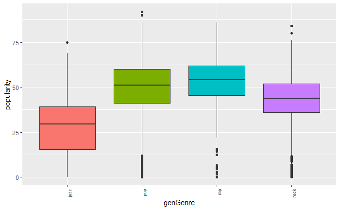

```r
new_genre_df <- rbind(rock_songs, only_rap_songs, only_jazz_songs, only_pop_songs)
new_genre_df %>% ggplot(aes(x=genGenre, y=popularity, fill = genGenre)) +
  geom_boxplot() +
  theme(axis.text.x = element_text(angle = 90, hjust = 1, size = 7)) +
  guides(fill=FALSE)
```

Analyzing specific Rock genres in dataframe and counting most popular genres:

```r
rock_songs_specific <- gsub(",.*", "", rock_songs$genres)
rock_songs_new <- cbind(rock_songs, rock_songs_specific)

rock_freq.df <- as.data.frame(table(rock_songs_new$rock_songs_specific))
rock_freq.df <- rock_freq.df[order(rock_freq.df$Freq, decreasing = TRUE) , ]
rock_freq.df
```

|  | Var1 | Freq |
| --- | --- | --- |
| 17 | ['album rock' | 309 |
| 26 | ['alternative metal' | 214 |
| 29 | ['alternative rock' | 184 |
| 7 | ['adult standards' | 148 |
| 235 | ['contemporary country' | 115 |
| 255 | ['dance rock' | 96 |
| 22 | ['alternative country' | 89 |
| 64 | ['art rock' | 77 |
| 112 | ['blues rock' | 72 |
| 23 | ['alternative dance' | 71 |

[output cut: 523 more lines]

[figure not shown]

```r
rock_songs_new %>% ggplot(aes(x=rock_songs_specific, y=popularity, fill=rock_songs_specific)) +
  geom_boxplot() +
  theme(axis.text.x = element_text(angle = 90, hjust = 1, size = 7)) +guides(fill=FALSE)
```

Loudness and popularity, then liveness and popularity for Rock songs:

```r
ggplot(data=rock_songs)+geom_point(aes(x=loudness,y=popularity))+labs(title="popularity VS loudness in rock music")
ggplot(data=rock_songs)+geom_point(aes(x=liveness,y=popularity))+labs(title="popularity VS liveness in rock music")
```

Same for Pop music:

```r
ggplot(data=only_pop_songs)+geom_point(aes(x=loudness,y=popularity))+labs(title="popularity VS loudness in pop music")
ggplot(data=only_pop_songs)+geom_point(aes(x=liveness,y=popularity))+labs(title="popularity VS liveness in pop music")
```

For Jazz:

```r
ggplot(data=only_jazz_songs)+geom_point(aes(x=loudness,y=popularity))+labs(title="popularity VS loudness in Jazz music")
ggplot(data=only_jazz_songs)+geom_point(aes(x=liveness,y=popularity))+labs(title="popularity VS liveness in Jazz music")
```

Lastly, for Rap:

```r
ggplot(data=only_rap_songs)+geom_point(aes(x=loudness,y=popularity))+labs(title="popularity VS loudness in Rap music")
ggplot(data=only_rap_songs)+geom_point(aes(x=liveness,y=popularity))+labs(title="popularity VS liveness in Rap music")
```

Plotting the relationship between duration and popularity for rap songs.

```r
durationrap<-ggplot(only_rap_songs,aes(duration_ms, popularity))+
  geom_point()+geom_smooth(aes(duration_ms,popularity),method = "lm")+labs(x="duration in mins")+
  ggtitle("Rap and Rap subgenres")+theme(plot.title=element_text(hjust=0.5))
durationrap
```

Plotting the relationship for all other three genres:

```r
rock_songs%>%ggplot(aes(log(duration_ms),log(popularity)))+geom_point()+geom_smooth(aes(log(duration_ms),log(popularity)),method = "lm")
only_jazz_songs%>%ggplot(aes(duration_ms,popularity))+geom_point()+geom_smooth(aes(duration_ms,popularity), method = "lm")
only_pop_songs%>%ggplot(aes(duration_ms,popularity))+geom_point()+geom_smooth(aes(duration_ms,popularity),method = "lm")
```

```r
rock_songs<-rock_songs%>%filter(popularity>0)
only_jazz_songs<-only_jazz_songs%>%filter(popularity>0)
only_pop_songs<-only_pop_songs%>%filter(popularity>0)
only_rap_songs<-only_rap_songs%>%filter(popularity>0)
```

Looking into the correlations for duration, and popularity for the four main genres:

```r
cor(rock_songs$popularity,rock_songs$duration_ms)
cor(only_jazz_songs$popularity,only_jazz_songs$duration_ms)
cor(only_pop_songs$popularity,only_pop_songs$duration_ms)
cor(only_rap_songs$popularity,only_rap_songs$duration_ms)
```

Reproducing correlational matrices for the four main genre groups:

```r
CorMatrixJazz<-cor(only_jazz_songs[,c("acousticness","danceability","duration_ms","energy","instrumentalness","liveness","speechiness","tempo","valence","popularity")])
CorMatrixRock<-cor(rock_songs[,c("acousticness","danceability","duration_ms","energy","instrumentalness","liveness","speechiness","tempo","valence","popularity")])
CorMatrixPop<-cor(only_pop_songs[,c("acousticness","danceability","duration_ms","energy","instrumentalness","liveness","speechiness","tempo","valence","popularity")])
CorMatrixRap<-cor(only_rap_songs[,c("acousticness","danceability","duration_ms","energy","instrumentalness","liveness","speechiness","tempo","valence","popularity")])
```

Saving the heatmap matrices:

```r
png(height = 1200, width = 1500, pointsize = 15, filename = "matrixRap2.png")
ggcorrplot(CorMatrixJazz,lab=TRUE,color=c("blue","white","red"),title="Correlation Matrix Jazz")+theme(plot.title=element_text(hjust=0.5, size = 0.1))
png(height = 1200, width = 1500, pointsize = 15, filename = "matrixRap2.png")
ggcorrplot(CorMatrixRock,lab=TRUE,color=c("blue","white","red"),title="Correlation Matrix Rock")+theme(plot.title=element_text(hjust=0.5, size = 0.1))
png(height = 1200, width = 1500, pointsize = 15, filename = "matrixRap2.png")
ggcorrplot(CorMatrixPop,lab=TRUE,color=c("blue","white","red"),title="Correlation Matrix Pop")+theme(plot.title=element_text(hjust=0.5, size = 0.1))
png(height = 1200, width = 1500, pointsize = 15, filename = "matrixRap2.png")
ggcorrplot(CorMatrixRap,lab=TRUE,color=c("blue","white","red"),title="Correlation Matrix Rap")+theme(plot.title=element_text(hjust=0.5, size = 0.1))
```

CHECKING THE TABLES SO WE CAN RUN A MULTIPLE LINEAR REGRESSION ON:

Y= Popularity X1= Duration X2=Danceability X3=Energy X4=Liveness X5 = Loudness

The following models are divided into 1 and 2. The first is the one with only variables first analyzed by us: danceability, duration, energy, liveness, loudness; The second will include all numerical variables in the Spotify data that were first analyzed but did not seem significant at the time. Summaries are both for models 1 and 2:

Model for Rock:

```r
linearModelRock1<-lm(formula=popularity~danceability+duration_ms+energy+liveness+loudness,data = rock_songs)
linearModelRock2<-lm(popularity~acousticness+danceability+duration_ms+energy+instrumentalness+liveness+loudness+speechiness+tempo+valence+popularity,data = rock_songs)
```

```
the response appeared on the right-hand side and was droppedproblem with term 11 in model.matrix: no columns are assigned
```

```r
summary(linearModelRock1)
```

```
Call:
lm(formula = popularity ~ danceability + duration_ms + energy +
    liveness + loudness, data = rock_songs)

Residuals:
    Min      1Q  Median      3Q     Max
-53.978  -6.081   0.065   6.354  62.073

Coefficients:
               Estimate Std. Error t value Pr(>|t|)
(Intercept)   5.859e+01  1.683e+00  34.819  < 2e-16 ***
danceability  7.726e+00  1.258e+00   6.140 9.00e-10 ***
duration_ms   2.392e-05  2.414e-06   9.909  < 2e-16 ***
energy       -1.185e+01  1.286e+00  -9.221  < 2e-16 ***
liveness     -6.905e+00  1.401e+00  -4.928 8.64e-07 ***
loudness      1.810e+00  6.782e-02  26.684  < 2e-16 ***
---
Signif. codes:  0 ‘***’ 0.001 ‘**’ 0.01 ‘*’ 0.05 ‘.’ 0.1 ‘ ’ 1

Residual standard error: 9.989 on 4164 degrees of freedom
Multiple R-squared:  0.2078,    Adjusted R-squared:  0.2069
F-statistic: 218.5 on 5 and 4164 DF,  p-value: < 2.2e-16
```

```r
summary(linearModelRock2)
```

```
Call:
lm(formula = popularity ~ acousticness + danceability + duration_ms +
    energy + instrumentalness + liveness + loudness + speechiness +
    tempo + valence + popularity, data = rock_songs)

Residuals:
    Min      1Q  Median      3Q     Max
-42.524  -5.791  -0.406   5.910  57.120

Coefficients:
                   Estimate Std. Error t value Pr(>|t|)
(Intercept)       6.047e+01  2.197e+00  27.527  < 2e-16 ***
acousticness     -8.261e+00  8.861e-01  -9.323  < 2e-16 ***
danceability      2.361e+01  1.547e+00  15.266  < 2e-16 ***
duration_ms       7.028e-06  2.458e-06   2.859  0.00427 **
energy           -1.056e+01  1.677e+00  -6.296 3.37e-10 ***
instrumentalness -2.136e+00  8.623e-01  -2.477  0.01329 *
liveness         -3.965e+00  1.343e+00  -2.953  0.00317 **
loudness          1.469e+00  6.972e-02  21.070  < 2e-16 ***
speechiness      -1.590e+01  3.012e+00  -5.279 1.37e-07 ***
tempo             2.192e-02  7.724e-03   2.837  0.00457 **
valence          -1.866e+01  1.017e+00 -18.351  < 2e-16 ***
---
Signif. codes:  0 ‘***’ 0.001 ‘**’ 0.01 ‘*’ 0.05 ‘.’ 0.1 ‘ ’ 1

Residual standard error: 9.435 on 4159 degrees of freedom
Multiple R-squared:  0.2941,    Adjusted R-squared:  0.2925
F-statistic: 173.3 on 10 and 4159 DF,  p-value: < 2.2e-16
```

The second completed model increases R-square for rock from 0.20 to 0.29

Model for Jazz:

```r
linearModelJazz1<-lm(popularity~danceability+duration_ms+energy+liveness+loudness,data=only_jazz_songs)
linearModelJazz2<-lm(popularity~acousticness+danceability+duration_ms+energy+instrumentalness+liveness+speechiness+tempo+valence+popularity,data=only_jazz_songs)
summary(linearModelJazz1)
summary(linearModelJazz2)
```

Model for Pop:

```r
linearModelPop1<-lm(popularity~danceability+duration_ms+energy+liveness+loudness,data=only_pop_songs)
linearModelPop2<-lm(popularity~acousticness+danceability+duration_ms+energy+instrumentalness+liveness+speechiness+tempo+valence+popularity,data=only_pop_songs)
summary(linearModelPop1)
summary(linearModelPop2)
```

Model for Rap:

```r
linearModelRap1<-lm(popularity~duration_ms+energy+liveness+loudness,data=only_rap_songs)
linearModelRap2<-lm(popularity~acousticness+danceability+duration_ms+energy+instrumentalness+liveness+speechiness+tempo+valence+popularity,data=only_rap_songs)
summary(linearModelRap1)
summary(linearModelRap2)
```

First, looking into a boxcox to check what transformation is appropriate for model 1 and 2:

```r
library(MASS)
bcRock<-boxcox(lm(popularity~acousticness+danceability+duration_ms+energy+instrumentalness+liveness+speechiness+tempo+valence+popularity,data=rock_songs))
bcJazz<-boxcox(lm(popularity~acousticness+danceability+duration_ms+energy+instrumentalness+liveness+speechiness+tempo+valence+popularity,data=only_jazz_songs))
bcPop<-boxcox(lm(popularity~acousticness+danceability+duration_ms+energy+instrumentalness+liveness+speechiness+tempo+valence+popularity,data=only_pop_songs))
bcRap<-boxcox(lm(popularity~acousticness+danceability+duration_ms+energy+instrumentalness+liveness+speechiness+tempo+valence+popularity,data=only_rap_songs))
lambdaRock<-bcRock$x[which(bcRock$y==max(bcRock$y))]
lambdaJazz<-bcJazz$x[which(bcJazz$y==max(bcJazz$y))]
lambdaPop<-bcPop$x[which(bcPop$y==max(bcPop$y))]
lambdaRap<-bcRap$x[which(bcRap$y==max(bcRap$y))]
round(lambdaRock,2)
round(lambdaJazz,2)
round(lambdaPop,2)
round(lambdaRap,2)
```

(y^1.64 - 1 /1.64)

Trying transformation for the rap model:

```r
gala<-lm((popularity^2-1/2)~acousticness+danceability+duration_ms+energy+instrumentalness+liveness+speechiness+tempo+valence,data=only_rap_songs)
plot(fitted(gala),resid(gala),col="dodgerblue", pch=20, cex=1.5, xlab="Fitted", ylab = "Residuals")
abline(h=0,lty=2,col="darkorange",lwd=2)
```

```r
TransformedRapModel<-lm((popularity^1.64-1/1.64)~acousticness+danceability+duration_ms+energy+instrumentalness+liveness+speechiness+tempo+valence,data=only_rap_songs)
summary(TransformedRapModel)
```

R-SQUARED: 0.2749. Model without speechiness that has such a high p-value:

```r
TransformedRapModel2<-lm((popularity^1.64-1/1.64)~acousticness+danceability+duration_ms+energy+instrumentalness+liveness+tempo+valence,data=only_rap_songs)
summary(TransformedRapModel)
```

```
Call:
lm(formula = (popularity^1.64 - 1/1.64) ~ acousticness + danceability +
    duration_ms + energy + instrumentalness + liveness + speechiness +
    tempo + valence, data = only_rap_songs)

Residuals:
    Min      1Q  Median      3Q     Max
-836.69 -128.22   -8.54  127.11  804.06

Coefficients:
                   Estimate Std. Error t value Pr(>|t|)
(Intercept)       9.155e+02  6.198e+01  14.770  < 2e-16 ***
acousticness      1.212e+02  3.384e+01   3.580 0.000353 ***
danceability      2.052e+02  4.671e+01   4.393 1.19e-05 ***
duration_ms      -1.614e-03  9.387e-05 -17.192  < 2e-16 ***
energy            1.612e+02  4.381e+01   3.679 0.000242 ***
instrumentalness -2.150e+02  4.651e+01  -4.623 4.07e-06 ***
liveness         -1.300e+02  4.530e+01  -2.869 0.004173 **
speechiness      -4.331e+01  4.718e+01  -0.918 0.358847
tempo             8.996e-01  2.276e-01   3.953 8.03e-05 ***
valence          -3.389e+02  3.051e+01 -11.107  < 2e-16 ***
---
Signif. codes:  0 ‘***’ 0.001 ‘**’ 0.01 ‘*’ 0.05 ‘.’ 0.1 ‘ ’ 1

Residual standard error: 197.5 on 1674 degrees of freedom
Multiple R-squared:  0.2749,    Adjusted R-squared:  0.271
F-statistic: 70.51 on 9 and 1674 DF,  p-value: < 2.2e-16
```

```r
summary(TransformedRapModel2)
```

```
Call:
lm(formula = (popularity^1.64 - 1/1.64) ~ acousticness + danceability +
    duration_ms + energy + instrumentalness + liveness + tempo +
    valence, data = only_rap_songs)

Residuals:
    Min      1Q  Median      3Q     Max
-832.17 -128.43   -8.22  126.93  809.30

Coefficients:
                   Estimate Std. Error t value Pr(>|t|)
(Intercept)       9.116e+02  6.184e+01  14.742  < 2e-16 ***
acousticness      1.215e+02  3.384e+01   3.590 0.000340 ***
danceability      1.991e+02  4.623e+01   4.306 1.76e-05 ***
duration_ms      -1.609e-03  9.371e-05 -17.169  < 2e-16 ***
energy            1.640e+02  4.371e+01   3.752 0.000181 ***
instrumentalness -2.078e+02  4.583e+01  -4.533 6.22e-06 ***
liveness         -1.358e+02  4.485e+01  -3.027 0.002506 **
tempo             8.978e-01  2.275e-01   3.946 8.29e-05 ***
valence          -3.423e+02  3.027e+01 -11.308  < 2e-16 ***
---
Signif. codes:  0 ‘***’ 0.001 ‘**’ 0.01 ‘*’ 0.05 ‘.’ 0.1 ‘ ’ 1

Residual standard error: 197.5 on 1675 degrees of freedom
Multiple R-squared:  0.2745,    Adjusted R-squared:  0.2711
F-statistic: 79.23 on 8 and 1675 DF,  p-value: < 2.2e-16
```

```r
AIC(TransformedRapModel)
```

```
[1] 22593.56
```

```r
AIC(TransformedRapModel2)
```

```
[1] 22592.4
```

Second model has lower AIC, so we are going to use that one for Rap:

Tranformations for Rock:

(y^lambda - 1 / lambda)